# Introduction into ggplot2

# Geometries

ggplot can create a huge variety of different types of plots. A selection can be found here on this ggplot cheat sheet [here](https://rstudio.github.io/cheatsheets/data-visualization.pdf). On top of that many R packages with very specific types of visualizations are developed on the basis of ggplot. So they work using the same syntax.

## Exercise 1

Let’s try to reproduce some parts of the SARS-CoV-2 paper of Figure 1 to visualize the distribution of the cohort using ggplot2.

1. Have a look at Figure 1 (panel c and d) of the paper before starting this exercise. https://doi.org/10.1038/s41586-020-03148-w
2. Use the `geom_boxplot()` geometry to create a boxplot that visualizes the distribution of age of the patients across the different groups of diagnosis (Fig. 1, panel c). Hint: Don´t overthink!
3. It is also useful to not only plot the boxes, but the data points itself. You can check on the internet or the cheat sheet above which geometry plots the points on top of the boxplot.
4. It would be nicer if the boxes had different colors, and if we could add a title to the plot. Are you happy with your plot? You can always ask ChatGPT for additional help to improve your plot and add layer-by-layer.
5. Challenging: Compute the **proportion** of sexes for the different diagnosis groups (Fig. 1, panel d) using the tidyverse functions `group_by()`, `summarise()` and `mutate()` visualize it in a **stacked bar chart**. Change the colors, fontsizes or anything of the plot until you like your plot.

**Answer**

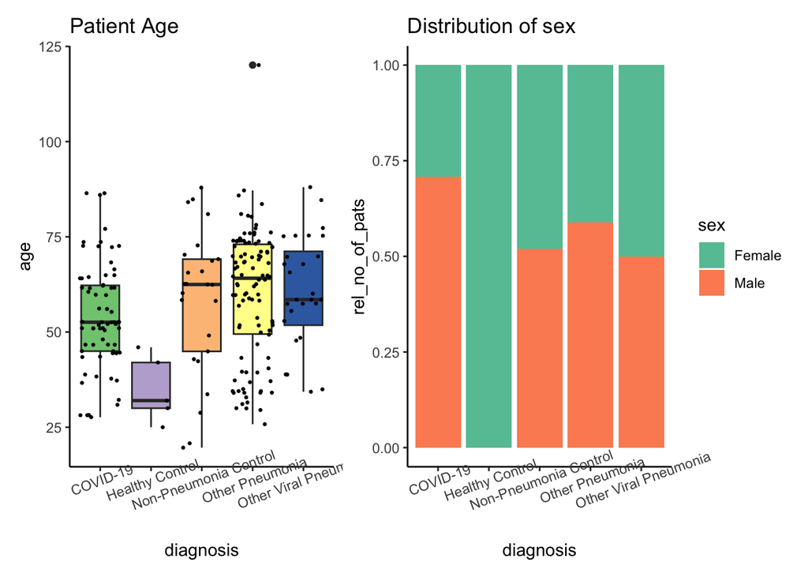

```r
# 1-4
patient_age_plot <- ggplot(meta, aes(x = diagnosis, y = age, fill = diagnosis)) +
  geom_boxplot() +
  geom_jitter(size = 0.5) +
  theme_classic() +
  theme(axis.text.x = element_text(angle = 20)) +
  scale_fill_brewer(palette="Accent") +
  ggtitle("Patient Age") +
  theme(legend.position = "none")

# compute summary statistics
sex_to_plot <- meta %>%
  dplyr::group_by(diagnosis, sex) %>%
  dplyr::summarise(number_of_patients = n()) %>%
  mutate(rel_no_of_pats = number_of_patients/sum(number_of_patients))

#stacked bar chart
plot_sex <- ggplot(sex_to_plot, aes(x = diagnosis, y = rel_no_of_pats, fill = sex)) +
  geom_col() +
  theme_classic() +
  scale_fill_brewer(palette="Set2") +
  theme(axis.text.x = element_text(angle = 20)) +
  ggtitle("Distribution of sex")

#using the patchwork library, we can align plots easily
patient_age_plot + plot_sex
```

## Additional: Aligning plots using patchwork

`patchwork` is a framework that makes it “ridiculously simple to combine separate ggplots into the same graphic”. You can check out the documentation [here](https://patchwork.data-imaginist.com).

The most basic example is to align two plots side by side using the `+` (as you can see in the solutions of the previous excercise).

In the documentation you can find out how to align plots underneath each other, and create much more complex panels of figures.

My favorite functionality though is to already at alphabetical tags for each subplot as shown below. Can you find out how to recreate this plot?

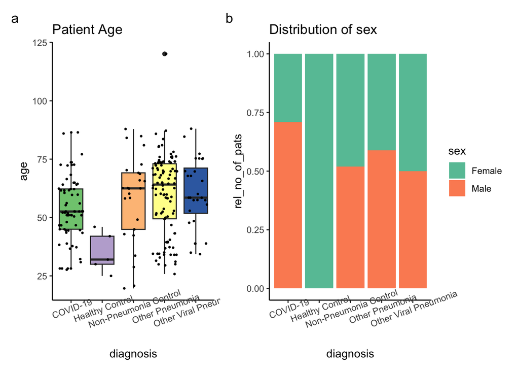

**Answer**

```r
(patient_age_plot + plot_sex) +
  plot_annotation(tag_levels = 'a')
```